# Homework 3 Report

Wojciech Michaluk

2022-11-23

## Wstęp

Celem mojego badania było sprawdzenie dokładności odczytu danych z wykresu kołowego 3D oraz kolumnowego. Zbadałem również wpływ kolorów na klasyfikację danych znajdujących się na wykresach.

## Przebieg badania

Najpierw na podstawie znalezionych w internecie danych przygotowałem 4 wykresy. Kołowy 3D, kolumnowy oraz dwie chmury słów. Następnie stworzyłem formularz zawierający wspomniane wykresy. Do każdego z nich zadałem respondentom 2 pytania.

Uzyskałem 32 odpowiedzi w ankietach. Na ich podstawie wyciągnąłem wnioski do postawionych pytań.

## Szacowanie wartości z wykresu

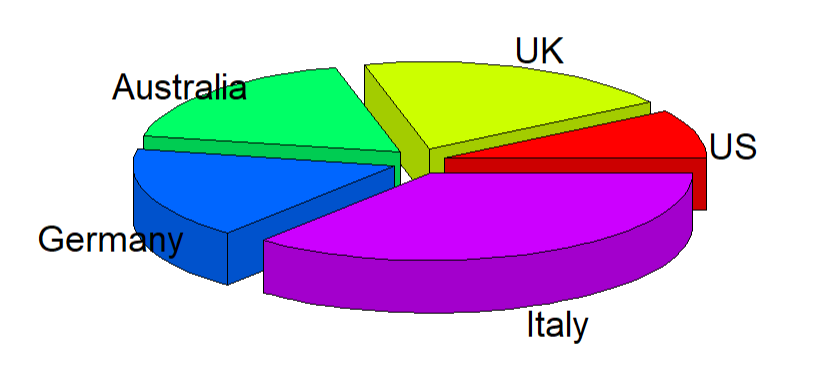

pie chart 3D

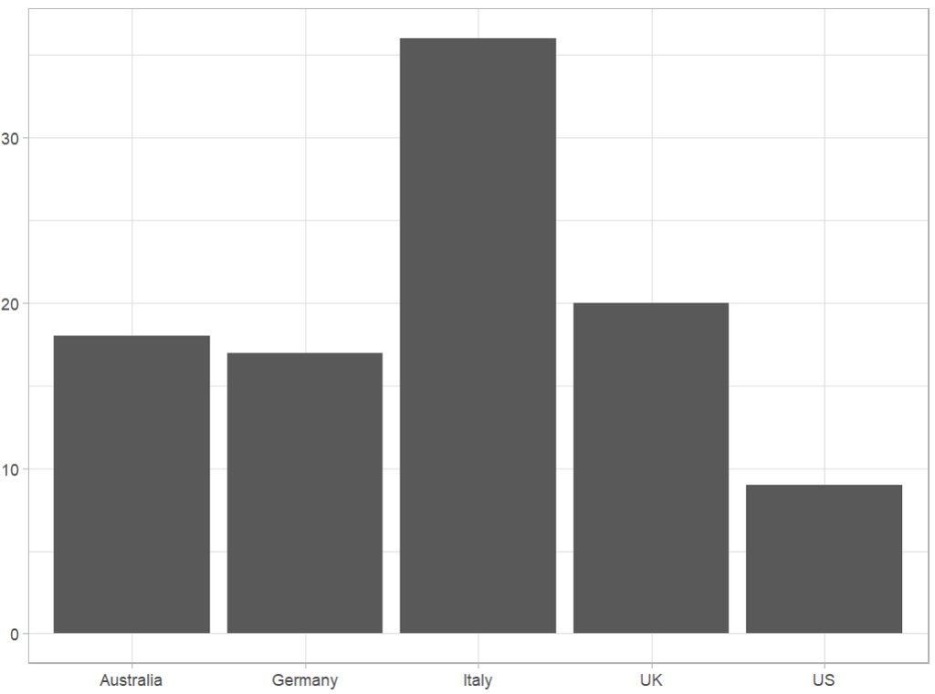

geom bar

### Ile % udziałów posiada kraj “Germany”?

Poprosiłem respondentów, aby oszacowali wartość przedstawioną na wykresie na podstawie jego wyglądu. Wyniki były następujące:

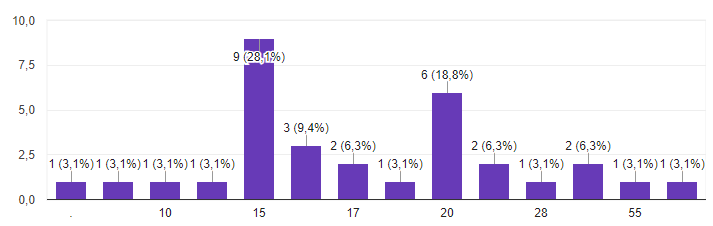

summary Pie Chart

1. Wykres Kołowy 3D

wartość dokładna: 17

procent dobrych odpowiedzi: 6,3%

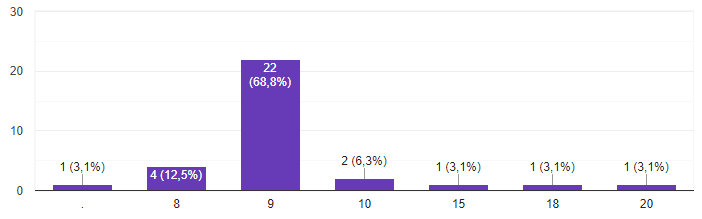

summary Geom Bar

2. Wykres Kolumnowy

wartość dokładna: 9

procent dobrych odpowiedzi: 68,8%%

**Wniosek:**

**Zdecydowanie trafniej szacowane były wartości z wykresu kolumnowego.**

### Ile razy większy udział posiada kraj “Australia”, niż “US”?

Poprosiłem respondentów, aby porównali dane wielkości przedstawione na wykresie. Chciałem, żeby ocenili o ile razy dana wielkość jest większa od innej.

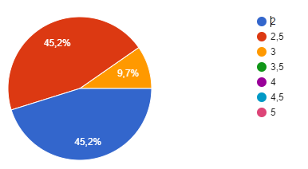

summary Pie Chart

1. Wykres Kołowy 3D

poprawne porównanie: 2 x większy

procent dobrych odpowiedzi: 45,2%

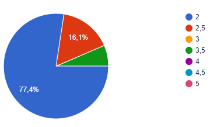

summary Geom Bar

2. Wykres Kolumnowy

poprawne porównanie: 2 x większy

procent dobrych odpowiedzi: 77,4%

**Wniosek:**

**Respondenci zdecydowanie lepiej porównywali wielkości na wykresie kolumnowym.**